# Ford GoBike Data Analysis

## by Saleh Sadek Rekaby

## Preliminary Wrangling

This data set includes information about a bike-sharing system, Ford GoBike system, in California's San Francisco Bay Area.

```python
# import all packages and set plots to be embedded inline
import numpy as np
import pandas as pd
import matplotlib.pyplot as plt
import seaborn as sb
%matplotlib inline
from datetime import datetime
```

```python
# read fordgobike-tripdata csv file.
fordgobike_df = pd.read_csv('201902-fordgobike-tripdata.csv')
# veiw the Dataset.
fordgobike_df.head()
```

|  | duration_sec | start_time | end_time | start_station_id | start_station_name | start_station_latitude | start_station_longitude | end_station_id | end_station_name | end_station_latitude | end_station_longitude | bike_id | user_type | member_birth_year | member_gender | bike_share_for_all_trip |
| --- | --- | --- | --- | --- | --- | --- | --- | --- | --- | --- | --- | --- | --- | --- | --- | --- |
| 0 | 52185 | 2019-02-28 17:32:10.1450 | 2019-03-01 08:01:55.9750 | 21.0 | Montgomery St BART Station (Market St at 2nd St) | 37.789625 | -122.400811 | 13.0 | Commercial St at Montgomery St | 37.794231 | -122.402923 | 4902 | Customer | 1984.0 | Male | No |
| 1 | 42521 | 2019-02-28 18:53:21.7890 | 2019-03-01 06:42:03.0560 | 23.0 | The Embarcadero at Steuart St | 37.791464 | -122.391034 | 81.0 | Berry St at 4th St | 37.775880 | -122.393170 | 2535 | Customer | NaN | NaN | No |
| 2 | 61854 | 2019-02-28 12:13:13.2180 | 2019-03-01 05:24:08.1460 | 86.0 | Market St at Dolores St | 37.769305 | -122.426826 | 3.0 | Powell St BART Station (Market St at 4th St) | 37.786375 | -122.404904 | 5905 | Customer | 1972.0 | Male | No |
| 3 | 36490 | 2019-02-28 17:54:26.0100 | 2019-03-01 04:02:36.8420 | 375.0 | Grove St at Masonic Ave | 37.774836 | -122.446546 | 70.0 | Central Ave at Fell St | 37.773311 | -122.444293 | 6638 | Subscriber | 1989.0 | Other | No |
| 4 | 1585 | 2019-02-28 23:54:18.5490 | 2019-03-01 00:20:44.0740 | 7.0 | Frank H Ogawa Plaza | 37.804562 | -122.271738 | 222.0 | 10th Ave at E 15th St | 37.792714 | -122.248780 | 4898 | Subscriber | 1974.0 | Male | Yes |

```python
# information about the dataset
fordgobike_df.info()
```

```
<class 'pandas.core.frame.DataFrame'>
RangeIndex: 183412 entries, 0 to 183411
Data columns (total 16 columns):
 #   Column                   Non-Null Count   Dtype
---  ------                   --------------   -----
 0   duration_sec             183412 non-null  int64
 1   start_time               183412 non-null  object
 2   end_time                 183412 non-null  object
 3   start_station_id         183215 non-null  float64
 4   start_station_name       183215 non-null  object
 5   start_station_latitude   183412 non-null  float64
 6   start_station_longitude  183412 non-null  float64
 7   end_station_id           183215 non-null  float64
 8   end_station_name         183215 non-null  object
 9   end_station_latitude     183412 non-null  float64
 10  end_station_longitude    183412 non-null  float64
 11  bike_id                  183412 non-null  int64
 12  user_type                183412 non-null  object
 13  member_birth_year        175147 non-null  float64
 14  member_gender            175147 non-null  object
 15  bike_share_for_all_trip  183412 non-null  object
dtypes: float64(7), int64(2), object(7)
memory usage: 22.4+ MB
```

```python
# explor Null values.
fordgobike_df.isnull().sum()
```

```
duration_sec                  0
start_time                    0
end_time                      0
start_station_id            197
start_station_name          197
start_station_latitude        0
start_station_longitude       0
end_station_id              197
end_station_name            197
end_station_latitude          0
end_station_longitude         0
bike_id                       0
user_type                     0
member_birth_year          8265
member_gender              8265
bike_share_for_all_trip       0
dtype: int64
```

```python
#chech for duplicated values.
fordgobike_df.duplicated().sum()
```

```
0
```

```python
# the shape of the dataframe.
fordgobike_df.shape
```

```
(183412, 16)
```

```python
# current date.
current_datetime =datetime.now()
current_year =current_datetime.year
print(current_year)
```

```
2021
```

### What is the structure of your dataset?

- The data set contains trip data of users in San Francisco Bay Area with fields as :-
- There are 183412 observations of the trip in the dataset with 16 columns.
  - Trip Duration(in seconds).
  - Start Time and Date.
  - End Time and Date.
  - Start Station ID.
  - Start Station Name.
  - Start Station Latitude.
  - Start Station Longitude.
  - End Station ID.
  - End Station Name.
  - End Station Latitude.
  - End Station Longitude.
  - Bike ID.
  - User Type (Subscriber or Customer – “Subscriber” = Member or “Customer” = Casual).
  - Member Year of Birth.
  - Member Gender.
  - bike share for all trip.
- Most variables are numeric in nature, while the variables,start_station_name,end_station_name,member_gender, user_type,bike_share_for_all_trip, are cateogrical in nature.
- start_time,end_time, are datetime.

### What is/are the main feature(s) of interest in your dataset?

- I'm most interested in figuring out what features are best for predicting the Duration of the Trip in the dataset.
- Are there relations between the Trip duration, user type, gender,start station or end station.

### What features in the dataset do you think will help support your investigation into your feature(s) of interest?

- duration_sec.
- start_station_name.
- end_station_name.
- user_type.
- member_gender.

### Data wrangling.

### Qulity

- Missing Values :-
  - start_station_id : have 197 Null Values.
  - start_station_name : have 197 Null Values.
  - end_station_id : have 197 Null Values.
  - end_station_name : have 197 Null Values.
  - member_birth_year : have 8265 Null Values.
  - member_gender : have 8265 Null Values.
- start_station_id, end_station_id of float datatype.
- bike_id of integer datatype.
- start_time , end_time, are object datatype (str).
- outliers

### Tidiness

- no need for start_station_latitude, start_station_longitude, end_station_latitude, end_station_longitude columns.
- Add a new column for trip duration in minutes.
- Add a new column for Age.

## Data Cleaning

```python
#creat a copy of Dataframe.
fordgobike_clean_df=fordgobike_df.copy()
```

### Qulity

### Define

- Drop the Null Values in columns start_station_id : have 197 Null Values.
  - start_station_name : have 197 Null Values.
  - end_station_id : have 197 Null Values.
  - end_station_name : have 197 Null Values.
  - member_birth_year : have 8265 Null Values.
  - member_gender : have 8265 Null Values.

### Code

```python
# Remove Null Values.
fordgobike_clean_df.dropna(inplace=True)
fordgobike_clean_df
```

|  | duration_sec | start_time | end_time | start_station_id | start_station_name | start_station_latitude | start_station_longitude | end_station_id | end_station_name | end_station_latitude | end_station_longitude | bike_id | user_type | member_birth_year | member_gender | bike_share_for_all_trip |
| --- | --- | --- | --- | --- | --- | --- | --- | --- | --- | --- | --- | --- | --- | --- | --- | --- |
| 0 | 52185 | 2019-02-28 17:32:10.1450 | 2019-03-01 08:01:55.9750 | 21.0 | Montgomery St BART Station (Market St at 2nd St) | 37.789625 | -122.400811 | 13.0 | Commercial St at Montgomery St | 37.794231 | -122.402923 | 4902 | Customer | 1984.0 | Male | No |
| 2 | 61854 | 2019-02-28 12:13:13.2180 | 2019-03-01 05:24:08.1460 | 86.0 | Market St at Dolores St | 37.769305 | -122.426826 | 3.0 | Powell St BART Station (Market St at 4th St) | 37.786375 | -122.404904 | 5905 | Customer | 1972.0 | Male | No |
| 3 | 36490 | 2019-02-28 17:54:26.0100 | 2019-03-01 04:02:36.8420 | 375.0 | Grove St at Masonic Ave | 37.774836 | -122.446546 | 70.0 | Central Ave at Fell St | 37.773311 | -122.444293 | 6638 | Subscriber | 1989.0 | Other | No |
| 4 | 1585 | 2019-02-28 23:54:18.5490 | 2019-03-01 00:20:44.0740 | 7.0 | Frank H Ogawa Plaza | 37.804562 | -122.271738 | 222.0 | 10th Ave at E 15th St | 37.792714 | -122.248780 | 4898 | Subscriber | 1974.0 | Male | Yes |
| 5 | 1793 | 2019-02-28 23:49:58.6320 | 2019-03-01 00:19:51.7600 | 93.0 | 4th St at Mission Bay Blvd S | 37.770407 | -122.391198 | 323.0 | Broadway at Kearny | 37.798014 | -122.405950 | 5200 | Subscriber | 1959.0 | Male | No |
| ... | ... | ... | ... | ... | ... | ... | ... | ... | ... | ... | ... | ... | ... | ... | ... | ... |
| 183407 | 480 | 2019-02-01 00:04:49.7240 | 2019-02-01 00:12:50.0340 | 27.0 | Beale St at Harrison St | 37.788059 | -122.391865 | 324.0 | Union Square (Powell St at Post St) | 37.788300 | -122.408531 | 4832 | Subscriber | 1996.0 | Male | No |
| 183408 | 313 | 2019-02-01 00:05:34.7440 | 2019-02-01 00:10:48.5020 | 21.0 | Montgomery St BART Station (Market St at 2nd St) | 37.789625 | -122.400811 | 66.0 | 3rd St at Townsend St | 37.778742 | -122.392741 | 4960 | Subscriber | 1984.0 | Male | No |
| 183409 | 141 | 2019-02-01 00:06:05.5490 | 2019-02-01 00:08:27.2200 | 278.0 | The Alameda at Bush St | 37.331932 | -121.904888 | 277.0 | Morrison Ave at Julian St | 37.333658 | -121.908586 | 3824 | Subscriber | 1990.0 | Male | Yes |
| 183410 | 139 | 2019-02-01 00:05:34.3600 | 2019-02-01 00:07:54.2870 | 220.0 | San Pablo Ave at MLK Jr Way | 37.811351 | -122.273422 | 216.0 | San Pablo Ave at 27th St | 37.817827 | -122.275698 | 5095 | Subscriber | 1988.0 | Male | No |
| 183411 | 271 | 2019-02-01 00:00:20.6360 | 2019-02-01 00:04:52.0580 | 24.0 | Spear St at Folsom St | 37.789677 | -122.390428 | 37.0 | 2nd St at Folsom St | 37.785000 | -122.395936 | 1057 | Subscriber | 1989.0 | Male | No |

174952 rows × 16 columns

### Test

```python
#Test.
fordgobike_clean_df.isnull().sum()
```

```
duration_sec               0
start_time                 0
end_time                   0
start_station_id           0
start_station_name         0
start_station_latitude     0
start_station_longitude    0
end_station_id             0
end_station_name           0
end_station_latitude       0
end_station_longitude      0
bike_id                    0
user_type                  0
member_birth_year          0
member_gender              0
bike_share_for_all_trip    0
dtype: int64
```

### Define

> change datatype of:- start_station_id, end_station_id of float datatype. bike_id of integer datatype.to object (str) datatype .

### Code

```python
#change datatype to (str) datatype .
fordgobike_clean_df['start_station_id'] = fordgobike_clean_df['start_station_id'].astype(str)
fordgobike_clean_df['end_station_id'] = fordgobike_clean_df['end_station_id'].astype(str)
fordgobike_clean_df['bike_id'] = fordgobike_clean_df['bike_id'].astype(str)
```

### Test

```python
#Test.
fordgobike_clean_df.info()
```

```
<class 'pandas.core.frame.DataFrame'>
Int64Index: 174952 entries, 0 to 183411
Data columns (total 16 columns):
 #   Column                   Non-Null Count   Dtype
---  ------                   --------------   -----
 0   duration_sec             174952 non-null  int64
 1   start_time               174952 non-null  object
 2   end_time                 174952 non-null  object
 3   start_station_id         174952 non-null  object
 4   start_station_name       174952 non-null  object
 5   start_station_latitude   174952 non-null  float64
 6   start_station_longitude  174952 non-null  float64
 7   end_station_id           174952 non-null  object
 8   end_station_name         174952 non-null  object
 9   end_station_latitude     174952 non-null  float64
 10  end_station_longitude    174952 non-null  float64
 11  bike_id                  174952 non-null  object
 12  user_type                174952 non-null  object
 13  member_birth_year        174952 non-null  float64
 14  member_gender            174952 non-null  object
 15  bike_share_for_all_trip  174952 non-null  object
dtypes: float64(5), int64(1), object(10)
memory usage: 22.7+ MB
```

### Define

- Change start_time , end_time datatype to datetime.

### Code

```python
#Change start_time , end_time datatype to datetime.
fordgobike_clean_df['start_time'] = pd.to_datetime(fordgobike_clean_df.start_time)
fordgobike_clean_df['end_time'] = pd.to_datetime(fordgobike_clean_df.end_time)
```

### Test

```python
# test
fordgobike_clean_df.info()
```

```
<class 'pandas.core.frame.DataFrame'>
Int64Index: 174952 entries, 0 to 183411
Data columns (total 16 columns):
 #   Column                   Non-Null Count   Dtype
---  ------                   --------------   -----
 0   duration_sec             174952 non-null  int64
 1   start_time               174952 non-null  datetime64[ns]
 2   end_time                 174952 non-null  datetime64[ns]
 3   start_station_id         174952 non-null  object
 4   start_station_name       174952 non-null  object
 5   start_station_latitude   174952 non-null  float64
 6   start_station_longitude  174952 non-null  float64
 7   end_station_id           174952 non-null  object
 8   end_station_name         174952 non-null  object
 9   end_station_latitude     174952 non-null  float64
 10  end_station_longitude    174952 non-null  float64
 11  bike_id                  174952 non-null  object
 12  user_type                174952 non-null  object
 13  member_birth_year        174952 non-null  float64
 14  member_gender            174952 non-null  object
 15  bike_share_for_all_trip  174952 non-null  object
dtypes: datetime64[ns](2), float64(5), int64(1), object(8)
memory usage: 22.7+ MB
```

### Tidiness

### Define

- Drop columns that no need for it, start_station_latitude, start_station_longitude, end_station_latitude, end_station_longitude columns.

### Code

```python
#Drop columns that no need for it.
fordgobike_clean_df = fordgobike_clean_df.drop(['start_station_latitude', 'start_station_longitude', 'end_station_latitude', 'end_station_longitude'], axis=1)
```

### Test

```python
# test.
fordgobike_clean_df.info()
```

```
<class 'pandas.core.frame.DataFrame'>
Int64Index: 174952 entries, 0 to 183411
Data columns (total 12 columns):
 #   Column                   Non-Null Count   Dtype
---  ------                   --------------   -----
 0   duration_sec             174952 non-null  int64
 1   start_time               174952 non-null  datetime64[ns]
 2   end_time                 174952 non-null  datetime64[ns]
 3   start_station_id         174952 non-null  object
 4   start_station_name       174952 non-null  object
 5   end_station_id           174952 non-null  object
 6   end_station_name         174952 non-null  object
 7   bike_id                  174952 non-null  object
 8   user_type                174952 non-null  object
 9   member_birth_year        174952 non-null  float64
 10  member_gender            174952 non-null  object
 11  bike_share_for_all_trip  174952 non-null  object
dtypes: datetime64[ns](2), float64(1), int64(1), object(8)
memory usage: 17.4+ MB
```

### Define

- Add a new column for trip duration in minutes.

### Code

```python
# convert seconds to minutes.
fordgobike_clean_df['duration_min']=fordgobike_clean_df['duration_sec']/60
# set the datatype into float datatype.
fordgobike_clean_df['duration_min']=fordgobike_clean_df['duration_min'].astype(float)
```

### Test

```python
#Test.
fordgobike_clean_df.info()
```

```
<class 'pandas.core.frame.DataFrame'>
Int64Index: 174952 entries, 0 to 183411
Data columns (total 13 columns):
 #   Column                   Non-Null Count   Dtype
---  ------                   --------------   -----
 0   duration_sec             174952 non-null  int64
 1   start_time               174952 non-null  datetime64[ns]
 2   end_time                 174952 non-null  datetime64[ns]
 3   start_station_id         174952 non-null  object
 4   start_station_name       174952 non-null  object
 5   end_station_id           174952 non-null  object
 6   end_station_name         174952 non-null  object
 7   bike_id                  174952 non-null  object
 8   user_type                174952 non-null  object
 9   member_birth_year        174952 non-null  float64
 10  member_gender            174952 non-null  object
 11  bike_share_for_all_trip  174952 non-null  object
 12  duration_min             174952 non-null  float64
dtypes: datetime64[ns](2), float64(2), int64(1), object(8)
memory usage: 18.7+ MB
```

### Define

- Add a new column for Age

## code

```python
fordgobike_clean_df['age'] =(current_year - fordgobike_clean_df['member_birth_year']).astype(float)
```

## test

```python
#test
fordgobike_clean_df.head()
```

|  | duration_sec | start_time | end_time | start_station_id | start_station_name | end_station_id | end_station_name | bike_id | user_type | member_birth_year | member_gender | bike_share_for_all_trip | duration_min | age |
| --- | --- | --- | --- | --- | --- | --- | --- | --- | --- | --- | --- | --- | --- | --- |
| 0 | 52185 | 2019-02-28 17:32:10.145 | 2019-03-01 08:01:55.975 | 21.0 | Montgomery St BART Station (Market St at 2nd St) | 13.0 | Commercial St at Montgomery St | 4902 | Customer | 1984.0 | Male | No | 869.750000 | 37.0 |
| 2 | 61854 | 2019-02-28 12:13:13.218 | 2019-03-01 05:24:08.146 | 86.0 | Market St at Dolores St | 3.0 | Powell St BART Station (Market St at 4th St) | 5905 | Customer | 1972.0 | Male | No | 1030.900000 | 49.0 |
| 3 | 36490 | 2019-02-28 17:54:26.010 | 2019-03-01 04:02:36.842 | 375.0 | Grove St at Masonic Ave | 70.0 | Central Ave at Fell St | 6638 | Subscriber | 1989.0 | Other | No | 608.166667 | 32.0 |
| 4 | 1585 | 2019-02-28 23:54:18.549 | 2019-03-01 00:20:44.074 | 7.0 | Frank H Ogawa Plaza | 222.0 | 10th Ave at E 15th St | 4898 | Subscriber | 1974.0 | Male | Yes | 26.416667 | 47.0 |
| 5 | 1793 | 2019-02-28 23:49:58.632 | 2019-03-01 00:19:51.760 | 93.0 | 4th St at Mission Bay Blvd S | 323.0 | Broadway at Kearny | 5200 | Subscriber | 1959.0 | Male | No | 29.883333 | 62.0 |

```python
#Storing Dataframe to a csv file.
fordgobike_clean_df.to_csv('201902-fordgobike-tripdata_clean.csv',encoding='utf-8', index=False)
```

```python
#creat copy of dataframe.
fordgobike_clean_df2 = fordgobike_clean_df.copy()
```

```python
# age extreme values (more than 70 years old).
age_extreme_values=fordgobike_clean_df2[fordgobike_clean_df['age']> 70].age.count()
age_extreme_values
```

```
852
```

```python
#number of observation with duration greater than 60  minutes.
duration_extreme_values = (fordgobike_clean_df2['duration_min'] >60).sum()
duration_extreme_values
```

```
1386
```

### Define

- Remove Trip Duration Extreme Values.

## Code

```python
# new datafram with removed Extreme Trip duration Values.
fordgobike_clean_df2.drop(fordgobike_clean_df2[fordgobike_clean_df2['duration_min'] >60].index, inplace = True)
```

## test

```python
#test
fordgobike_clean_df2.head()
```

|  | duration_sec | start_time | end_time | start_station_id | start_station_name | end_station_id | end_station_name | bike_id | user_type | member_birth_year | member_gender | bike_share_for_all_trip | duration_min | age |
| --- | --- | --- | --- | --- | --- | --- | --- | --- | --- | --- | --- | --- | --- | --- |
| 4 | 1585 | 2019-02-28 23:54:18.549 | 2019-03-01 00:20:44.074 | 7.0 | Frank H Ogawa Plaza | 222.0 | 10th Ave at E 15th St | 4898 | Subscriber | 1974.0 | Male | Yes | 26.416667 | 47.0 |
| 5 | 1793 | 2019-02-28 23:49:58.632 | 2019-03-01 00:19:51.760 | 93.0 | 4th St at Mission Bay Blvd S | 323.0 | Broadway at Kearny | 5200 | Subscriber | 1959.0 | Male | No | 29.883333 | 62.0 |
| 6 | 1147 | 2019-02-28 23:55:35.104 | 2019-03-01 00:14:42.588 | 300.0 | Palm St at Willow St | 312.0 | San Jose Diridon Station | 3803 | Subscriber | 1983.0 | Female | No | 19.116667 | 38.0 |
| 7 | 1615 | 2019-02-28 23:41:06.766 | 2019-03-01 00:08:02.756 | 10.0 | Washington St at Kearny St | 127.0 | Valencia St at 21st St | 6329 | Subscriber | 1989.0 | Male | No | 26.916667 | 32.0 |
| 8 | 1570 | 2019-02-28 23:41:48.790 | 2019-03-01 00:07:59.715 | 10.0 | Washington St at Kearny St | 127.0 | Valencia St at 21st St | 6548 | Subscriber | 1988.0 | Other | No | 26.166667 | 33.0 |

```python
#number of observations with trip duration greater than 60 minute.
duration_extr = (fordgobike_clean_df2['duration_min'] >60).sum()
duration_extr
```

```
0
```

### Define

- Remove age Extreme Values.

## code

```python
# datafram with removed Extreme age Values.
fordgobike_clean_df2.drop(fordgobike_clean_df2[fordgobike_clean_df2['age'] >70].index,inplace = True)
```

## test

```python
fordgobike_clean_df2['age'].describe()
```

```
count    172719.000000
mean         35.976783
std           9.615333
min          20.000000
25%          29.000000
50%          34.000000
75%          41.000000
max          70.000000
Name: age, dtype: float64
```

```python
#number of observations with age greater than 70 years old.
age_extr = (fordgobike_clean_df2['age'] >70).sum()
age_extr
```

```
0
```

## Univariate Exploration

I'll start by looking at the distribution of the variable of interest: Trip Duration.

```python
# plotting Trip Duration as a numerical variable using histogram.
fordgobike_clean_df2['duration_min'].describe()
```

```
count    172719.000000
mean         10.311519
std           7.391044
min           1.016667
25%           5.366667
50%           8.450000
75%          13.000000
max          59.933333
Name: duration_min, dtype: float64
```

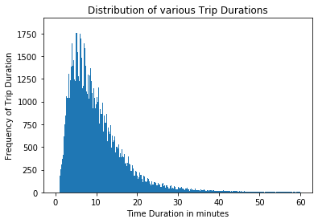

```python
# exploring Trip Duration in minutes.
bins = np.arange(0, fordgobike_clean_df2['duration_min'].max()+0.1, 0.1)
plt.hist(data = fordgobike_clean_df2 , x= 'duration_min', bins = bins);
plt.title('Distribution of various Trip Durations');
plt.xlabel('Time Duration in minutes');
plt.ylabel('Frequency of Trip Duration');
```

The histogram shows the distribution of Trip Duration, There is a long tail in the distribution, Which indicates the presence of little but with long duration trips, so let's put it on a log scale.

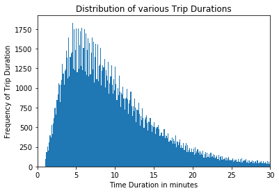

```python
# exploring Trip Duration with x limitation to 30 minutes.
bins = np.arange(0, fordgobike_clean_df2['duration_min'].max()+0.1, 0.1)
plt.hist(data = fordgobike_clean_df2 , x= 'duration_min', bins = bins);
plt.title('Distribution of various Trip Durations');
plt.xlabel('Time Duration in minutes');
plt.ylabel('Frequency of Trip Duration');
plt.xlim(0,30);
```

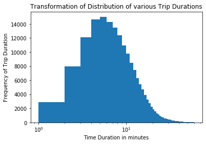

```python
# exploring Trip Duration in minutes.
#scale the x-axis to log-type.
bins = np.arange(0, fordgobike_clean_df2['duration_min'].max()+1, 1)
plt.hist(data = fordgobike_clean_df2 , x= 'duration_min', bins = bins);
plt.xscale('log')
plt.title('Transformation of Distribution of various Trip Durations');
plt.xlabel('Time Duration in minutes');
plt.ylabel('Frequency of Trip Duration');
```

The histogram shows the distribution of Trip Duration,on a log scale, There is a steady increase in trip duration with most of the values are less than 15 minutes.

```python
# Transform the describe() to a scale of log10.
np.log10(fordgobike_clean_df2['duration_min'].describe())
```

```
count    5.237340
mean     1.013323
std      0.868706
min      0.007179
25%      0.729705
50%      0.926857
75%      1.113943
max      1.777668
Name: duration_min, dtype: float64
```

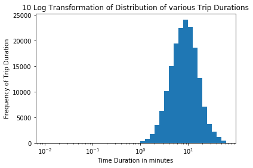

```python
# Axis transformation.
# Bin size.
bins = 10 ** np.arange(-2, np.log10(fordgobike_clean_df2['duration_min'].max())+0.1, 0.1)
plt.hist(data = fordgobike_clean_df2 , x= 'duration_min', bins = bins);
plt.xscale('log')
plt.title('10 Log Transformation of Distribution of various Trip Durations');
plt.xlabel('Time Duration in minutes');
plt.ylabel('Frequency of Trip Duration');
```

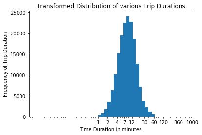

```python
# Axis transformation.
# Bin size.
bins = 10 ** np.arange(-2, np.log10(fordgobike_clean_df2['duration_min'].max())+0.1, 0.1)
# Generate the x-ticks.
ticks = [1,2,4,7,12,30,60,120,360, 1000]
# Convert ticks into string values, to be displaye along the x-axis
labels = ['{}'.format(v) for v in ticks]
plt.hist(data = fordgobike_clean_df2 , x= 'duration_min', bins = bins);
plt.xscale('log')

# Apply x-ticks
plt.xticks(ticks, labels);
plt.title('Transformed Distribution of various Trip Durations');
plt.xlabel('Time Duration in minutes');
plt.ylabel('Frequency of Trip Duration');
```

Histogram based on the custom scaling the given Trip Duration data Series,The histogram shows the distribution of Trip Duration, There is a steady increase in trip duration with most of the values are less than 12 minutes, with a peak of around 7 minutes.

### investigate the user age

```python
# statstics of age.
fordgobike_clean_df2.age.describe()
```

```
count    172719.000000
mean         35.976783
std           9.615333
min          20.000000
25%          29.000000
50%          34.000000
75%          41.000000
max          70.000000
Name: age, dtype: float64
```

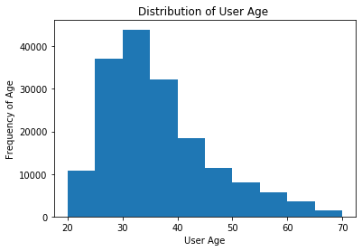

```python
# plotting user age.
plt.hist(data = fordgobike_clean_df2 , x= 'age');
plt.title('Distribution of User Age ')
plt.xlabel('User Age');
plt.ylabel('Frequency of Age');
```

A histogram show the majority of user age Distribution is under 45 years.

### investigate the user type

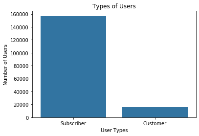

```python
# plotting types of users on bar chart as a catigorical data.
base_color = sb.color_palette()[0]
sb.countplot(data = fordgobike_clean_df2, x ='user_type', color = base_color)
plt.title('Types of Users')
plt.xlabel('User Types')
plt.ylabel('Number of Users');
```

Bar chart showing that the number of Subscribers (members) is very high, which reveals the loyalty of Subscribers and their dependency on ford gobike.

and move to the user gender

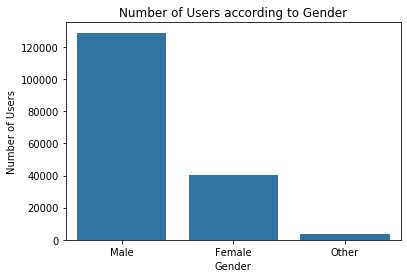

```python
# plotting gender on bar chart as a catigorical data.
base_color = sb.color_palette()[0]
sb.countplot(data = fordgobike_clean_df2, x ='member_gender', color = base_color)
plt.title('Number of Users according to Gender')
plt.xlabel('Gender')
plt.ylabel('Number of Users');
```

Bar chart showing that the number of Males is greater than females.

look for deep investigation if there are any changes if the start station and end station are the same.

```python
# Trips of same start-end Station.
same_station = fordgobike_clean_df2[fordgobike_clean_df2['start_station_name']==fordgobike_clean_df2['end_station_name']]
same_station
```

|  | duration_sec | start_time | end_time | start_station_id | start_station_name | end_station_id | end_station_name | bike_id | user_type | member_birth_year | member_gender | bike_share_for_all_trip | duration_min | age |
| --- | --- | --- | --- | --- | --- | --- | --- | --- | --- | --- | --- | --- | --- | --- |
| 19 | 874 | 2019-02-28 23:43:05.183 | 2019-02-28 23:57:39.796 | 180.0 | Telegraph Ave at 23rd St | 180.0 | Telegraph Ave at 23rd St | 5629 | Customer | 1978.0 | Male | No | 14.566667 | 43.0 |
| 27 | 408 | 2019-02-28 23:48:08.282 | 2019-02-28 23:54:56.930 | 78.0 | Folsom St at 9th St | 78.0 | Folsom St at 9th St | 5410 | Subscriber | 1982.0 | Male | No | 6.800000 | 39.0 |
| 34 | 471 | 2019-02-28 23:42:43.361 | 2019-02-28 23:50:34.446 | 133.0 | Valencia St at 22nd St | 133.0 | Valencia St at 22nd St | 5559 | Subscriber | 1992.0 | Male | No | 7.850000 | 29.0 |
| 55 | 3478 | 2019-02-28 22:39:35.020 | 2019-02-28 23:37:33.342 | 11.0 | Davis St at Jackson St | 11.0 | Davis St at Jackson St | 1846 | Subscriber | 1995.0 | Male | No | 57.966667 | 26.0 |
| 56 | 3140 | 2019-02-28 22:44:53.503 | 2019-02-28 23:37:14.090 | 11.0 | Davis St at Jackson St | 11.0 | Davis St at Jackson St | 3040 | Subscriber | 1983.0 | Female | No | 52.333333 | 38.0 |
| ... | ... | ... | ... | ... | ... | ... | ... | ... | ... | ... | ... | ... | ... | ... |
| 183307 | 758 | 2019-02-01 03:53:58.351 | 2019-02-01 04:06:36.653 | 385.0 | Woolsey St at Sacramento St | 385.0 | Woolsey St at Sacramento St | 4913 | Subscriber | 1987.0 | Male | No | 12.633333 | 34.0 |
| 183317 | 1476 | 2019-02-01 02:45:04.744 | 2019-02-01 03:09:41.184 | 345.0 | Hubbell St at 16th St | 345.0 | Hubbell St at 16th St | 5224 | Subscriber | 1967.0 | Male | No | 24.600000 | 54.0 |
| 183318 | 877 | 2019-02-01 02:53:15.995 | 2019-02-01 03:07:53.058 | 385.0 | Woolsey St at Sacramento St | 385.0 | Woolsey St at Sacramento St | 4913 | Subscriber | 1987.0 | Male | No | 14.616667 | 34.0 |
| 183350 | 874 | 2019-02-01 01:41:43.414 | 2019-02-01 01:56:17.552 | 253.0 | Haste St at College Ave | 253.0 | Haste St at College Ave | 3232 | Subscriber | 1995.0 | Male | Yes | 14.566667 | 26.0 |
| 183380 | 943 | 2019-02-01 00:43:11.550 | 2019-02-01 00:58:55.217 | 31.0 | Raymond Kimbell Playground | 31.0 | Raymond Kimbell Playground | 5343 | Subscriber | 1972.0 | Male | No | 15.716667 | 49.0 |

3142 rows × 14 columns

viewing the outcome.

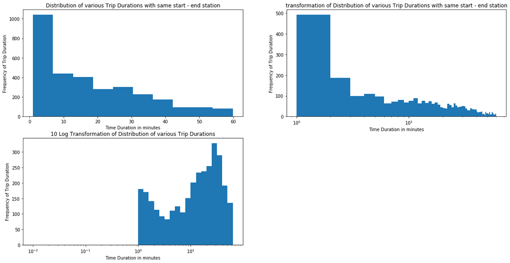

```python
fig = plt.figure(figsize=[20,10])
plt.subplot(2, 2, 1)
# Distribution of Trip duration of same start-end stations.
plt.hist(data = same_station , x= 'duration_min');
plt.title('Distribution of various Trip Durations with same start - end station');
plt.xlabel('Time Duration in minutes');
plt.ylabel('Frequency of Trip Duration');

plt.subplot(2, 2, 2)
# Transformation distribution of Trip duration of same start-end stations.
bins = np.arange(0, same_station['duration_min'].max()+1, 1)
plt.hist(data = same_station , x= 'duration_min', bins = bins);
plt.xscale('log')
plt.title('transformation of Distribution of various Trip Durations with same start - end station');
plt.xlabel('Time Duration in minutes');
plt.ylabel('Frequency of Trip Duration');

plt.subplot(2, 2, 3)
# Axis transformation.
# Bin size.
bins = 10 ** np.arange(-2, np.log10(same_station['duration_min'].max())+0.1, 0.1)
plt.hist(data = same_station , x= 'duration_min', bins = bins);
plt.xscale('log')
plt.title('10 Log Transformation of Distribution of various Trip Durations');
plt.xlabel('Time Duration in minutes');
plt.ylabel('Frequency of Trip Duration');
```

Subplots Histograms shows more skewed observations when the start station is same to end station, with bimodal histogram of trip duration frequency.

### Top 10 stations where the start is same to end station.

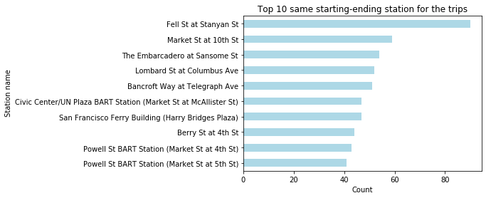

```python
top_same_station = same_station['start_station_name'].value_counts()[ :10].sort_values()
top_same_station.plot(kind = 'barh', color='lightblue')
plt.title('Top 10 same starting-ending station for the trips')
plt.xlabel('Count')
plt.ylabel(' Station name');
```

What if the stations are different.

```python
# when the start station is not the end station
not_same_station = fordgobike_clean_df2[fordgobike_clean_df2['start_station_name']!=fordgobike_clean_df2['end_station_name']]
not_same_station
```

|  | duration_sec | start_time | end_time | start_station_id | start_station_name | end_station_id | end_station_name | bike_id | user_type | member_birth_year | member_gender | bike_share_for_all_trip | duration_min | age |
| --- | --- | --- | --- | --- | --- | --- | --- | --- | --- | --- | --- | --- | --- | --- |
| 4 | 1585 | 2019-02-28 23:54:18.549 | 2019-03-01 00:20:44.074 | 7.0 | Frank H Ogawa Plaza | 222.0 | 10th Ave at E 15th St | 4898 | Subscriber | 1974.0 | Male | Yes | 26.416667 | 47.0 |
| 5 | 1793 | 2019-02-28 23:49:58.632 | 2019-03-01 00:19:51.760 | 93.0 | 4th St at Mission Bay Blvd S | 323.0 | Broadway at Kearny | 5200 | Subscriber | 1959.0 | Male | No | 29.883333 | 62.0 |
| 6 | 1147 | 2019-02-28 23:55:35.104 | 2019-03-01 00:14:42.588 | 300.0 | Palm St at Willow St | 312.0 | San Jose Diridon Station | 3803 | Subscriber | 1983.0 | Female | No | 19.116667 | 38.0 |
| 7 | 1615 | 2019-02-28 23:41:06.766 | 2019-03-01 00:08:02.756 | 10.0 | Washington St at Kearny St | 127.0 | Valencia St at 21st St | 6329 | Subscriber | 1989.0 | Male | No | 26.916667 | 32.0 |
| 8 | 1570 | 2019-02-28 23:41:48.790 | 2019-03-01 00:07:59.715 | 10.0 | Washington St at Kearny St | 127.0 | Valencia St at 21st St | 6548 | Subscriber | 1988.0 | Other | No | 26.166667 | 33.0 |
| ... | ... | ... | ... | ... | ... | ... | ... | ... | ... | ... | ... | ... | ... | ... |
| 183407 | 480 | 2019-02-01 00:04:49.724 | 2019-02-01 00:12:50.034 | 27.0 | Beale St at Harrison St | 324.0 | Union Square (Powell St at Post St) | 4832 | Subscriber | 1996.0 | Male | No | 8.000000 | 25.0 |
| 183408 | 313 | 2019-02-01 00:05:34.744 | 2019-02-01 00:10:48.502 | 21.0 | Montgomery St BART Station (Market St at 2nd St) | 66.0 | 3rd St at Townsend St | 4960 | Subscriber | 1984.0 | Male | No | 5.216667 | 37.0 |
| 183409 | 141 | 2019-02-01 00:06:05.549 | 2019-02-01 00:08:27.220 | 278.0 | The Alameda at Bush St | 277.0 | Morrison Ave at Julian St | 3824 | Subscriber | 1990.0 | Male | Yes | 2.350000 | 31.0 |
| 183410 | 139 | 2019-02-01 00:05:34.360 | 2019-02-01 00:07:54.287 | 220.0 | San Pablo Ave at MLK Jr Way | 216.0 | San Pablo Ave at 27th St | 5095 | Subscriber | 1988.0 | Male | No | 2.316667 | 33.0 |
| 183411 | 271 | 2019-02-01 00:00:20.636 | 2019-02-01 00:04:52.058 | 24.0 | Spear St at Folsom St | 37.0 | 2nd St at Folsom St | 1057 | Subscriber | 1989.0 | Male | No | 4.516667 | 32.0 |

169577 rows × 14 columns

```python
not_same_station.info()
```

```
<class 'pandas.core.frame.DataFrame'>
Int64Index: 169577 entries, 4 to 183411
Data columns (total 14 columns):
 #   Column                   Non-Null Count   Dtype
---  ------                   --------------   -----
 0   duration_sec             169577 non-null  int64
 1   start_time               169577 non-null  datetime64[ns]
 2   end_time                 169577 non-null  datetime64[ns]
 3   start_station_id         169577 non-null  object
 4   start_station_name       169577 non-null  object
 5   end_station_id           169577 non-null  object
 6   end_station_name         169577 non-null  object
 7   bike_id                  169577 non-null  object
 8   user_type                169577 non-null  object
 9   member_birth_year        169577 non-null  float64
 10  member_gender            169577 non-null  object
 11  bike_share_for_all_trip  169577 non-null  object
 12  duration_min             169577 non-null  float64
 13  age                      169577 non-null  float64
dtypes: datetime64[ns](2), float64(3), int64(1), object(8)
memory usage: 19.4+ MB
```

Give a look.

[figure not shown]

```python
fig = plt.figure(figsize=[20,10])
plt.subplot(2, 2, 1)
plt.hist(data = not_same_station , x= 'duration_min');
plt.title('Distribution of various Trip Durations with same start - end station');
plt.xlabel('Time Duration in minutes');
plt.ylabel('Frequency of Trip Duration');

plt.subplot(2, 2, 2)
# Transformation distribution of Trip duration of same start-end stations.
bins = np.arange(0, not_same_station['duration_min'].max()+1, 1)
plt.hist(data = not_same_station , x= 'duration_min', bins = bins);
plt.xscale('log')
plt.title('transformation of Distribution of various Trip Durations with same start - end station');
plt.xlabel('Time Duration in minutes');
plt.ylabel('Frequency of Trip Duration');

plt.subplot(2, 2, 3)
# Axis transformation.
# Bin size.
bins = 10 ** np.arange(-2, np.log10(not_same_station['duration_min'].max())+0.1, 0.1)
plt.hist(data = not_same_station , x= 'duration_min', bins = bins);
plt.xscale('log')
plt.title('10 Log Transformation of Distribution of various Trip Durations');
plt.xlabel('Time Duration in minutes');
plt.ylabel('Frequency of Trip Duration');
```

Subplots Histograms shows similar behavior to original observations when the start station is not same to end station.

Are there any changes in user type or gender, if the start station is the end station?

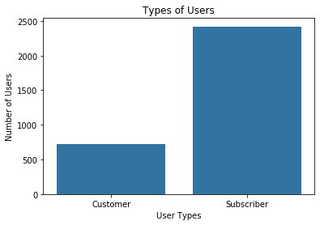

```python
# plotting according to user type of same stations.
base_color = sb.color_palette()[0]
sb.countplot(data = same_station, x ='user_type', color = base_color)
plt.title('Types of Users')
plt.xlabel('User Types')
plt.ylabel('Number of Users');
```

Bar chart show subscribers higher than customers where the start station is the same end station (same as original data).

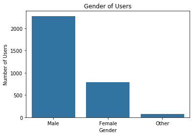

```python
# plotting according to gender of same stations.
base_color = sb.color_palette()[0]
sb.countplot(data = same_station, x ='member_gender', color = base_color)
plt.title('Gender of Users')
plt.xlabel('Gender')
plt.ylabel('Number of Users');
```

Bar chart show Males higher than Females where the start station is the same end station (same as original data).

### Of the features you investigated, were there any unusual distributions? Did you perform any operations on the data to tidy, adjust, or change the form of the data? If so, why did you do this?

> When performing more analysis on stations where the start station and end station are the same I find that, more skewed observations when the start station is same to end station, with bimodal histogram of trip duration frequency.

## Bivariate Exploration

Let's give a look at the pairwise correlations present between features in the data.

Starting with the effect of age on trip duration, Are elderly users take a long time?

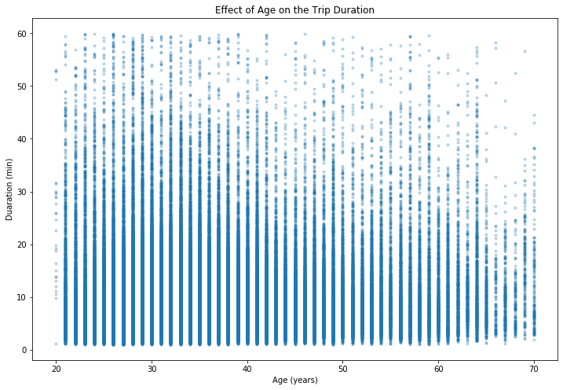

```python
# Trip duration disripution according to age of user.
plt.figure(figsize=[12,8])
plt.scatter(data =fordgobike_clean_df2 ,x= 'age', y='duration_min', alpha = 0.25, marker = '.' )
plt.title('Effect of Age on the Trip Duration')
plt.xlabel('Age (years)')
plt.ylabel('Duaration (min)');
```

A scatter plot shows a moderate decrease in trip duration in spite of the increase of Age.

Take a look at the effect of user type.

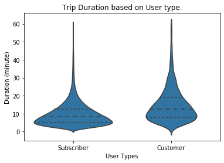

```python
#trip duration according to user type.
base_color = sb.color_palette()[0]
sb.violinplot(data=fordgobike_clean_df2, x='user_type', y='duration_min', color=base_color,inner='quartile');
plt.title('Trip Duration based on User type.');
plt.xlabel('User Types');
plt.ylabel('Duration (minute)');
```

A violin plot shows that there are much more subscriber users but with a lower trip duration average than the customers.

More look user type if the stations are the same.

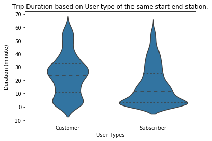

```python
#trip duration according to user type of the same start - end staion.
base_color = sb.color_palette()[0]
sb.violinplot(data=same_station, x='user_type', y='duration_min', color=base_color,inner='quartile');
plt.title('Trip Duration based on User type of the same start end station.');
plt.xlabel('User Types');
plt.ylabel('Duration (minute)');
```

A violin plot shows a different behavior of subscribers, a large number of subscribers take the minimum trip duration. Are they change their mind? (back to the same station). (also with a lower trip duration average, about 10 minutes).

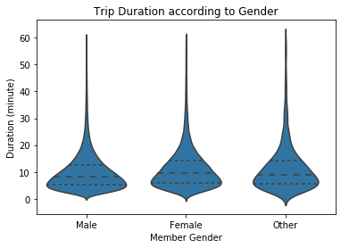

```python
#trip duration according to Gender.
base_color = sb.color_palette()[0]
sb.violinplot(data=fordgobike_clean_df2, x='member_gender', y='duration_min', color=base_color,inner='quartile');
plt.title('Trip Duration according to Gender');
plt.xlabel('Member Gender');
plt.ylabel('Duration (minute)');
```

A violin plot shows a parallel distribution of male, female, and other trip duration data, with a majority of trip duration data regarding the gender, which is less than 20 minutes.

Trip Duration according to Gender of the same start - end staion

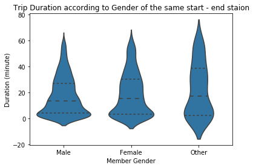

```python
#trip duration according to Gender of the same start - end staion.
base_color = sb.color_palette()[0]
sb.violinplot(data=same_station, x='member_gender', y='duration_min', color=base_color,inner='quartile');
plt.title('Trip Duration according to Gender of the same start - end staion');
plt.xlabel('Member Gender');
plt.ylabel('Duration (minute)');
```

A violin plot shows a distribution of male, female, and other trip duration data, with male and female data nearly of the same boundaries, and the same average trip duration of about 15 minutes(elevated trip duration average in comparison to original data), but other user data show a narrow distribution but elongated over a wide trip duration.

View User Type according to their Gender.

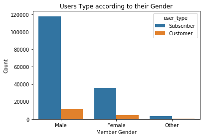

```python
sb.countplot(data = fordgobike_clean_df2, x = 'member_gender', hue = 'user_type');
plt.title('Users Type according to their Gender');
plt.xlabel('Member Gender');
plt.ylabel('Count');
```

Clustered Bar Charts view high male subscribers compared with customer user type and female of both user types.

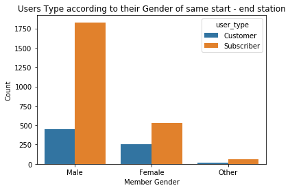

```python
sb.countplot(data = same_station, x = 'member_gender', hue = 'user_type');
plt.title('Users Type according to their Gender of same start - end station');
plt.xlabel('Member Gender');
plt.ylabel('Count');
```

Clustered Bar Charts view high male subscribers compared with customer user type and female of both user types even when the station is the same.

Take another look at the pairwise correlations present between Gender and user type in the data.

```python
# number of both user types according to their gender.
ct_counts = fordgobike_clean_df2.groupby(['member_gender', 'user_type']).size()
ct_counts
```

```
member_gender  user_type
Female         Customer        4388
               Subscriber     35927
Male           Customer       11014
               Subscriber    117845
Other          Customer         432
               Subscriber      3113
dtype: int64
```

```python
# Use Series.reset_index() to convert a series into a dataframe object
ct_counts = ct_counts.reset_index(name='count')
ct_counts
```

|  | member_gender | user_type | count |
| --- | --- | --- | --- |
| 0 | Female | Customer | 4388 |
| 1 | Female | Subscriber | 35927 |
| 2 | Male | Customer | 11014 |
| 3 | Male | Subscriber | 117845 |
| 4 | Other | Customer | 432 |
| 5 | Other | Subscriber | 3113 |

```python
# Use DataFrame.pivot() to rearrange the data.
ct_counts = ct_counts.pivot(index = 'member_gender', columns = 'user_type', values = 'count')
```

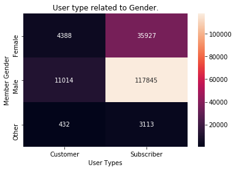

```python
sb.heatmap(ct_counts, annot = True, fmt = 'd');
plt.title('User type related to Gender.');
plt.xlabel('User Types');
plt.ylabel('Member Gender');
```

A heatmap view user type related to their gender.

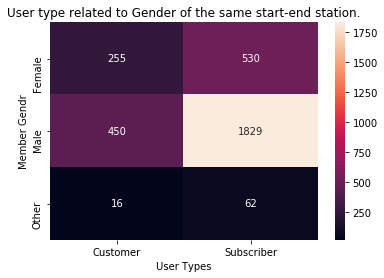

```python
same_station_counts = same_station.groupby(['member_gender', 'user_type']).size()
same_station_counts = same_station_counts.reset_index(name='count')
same_station_counts = same_station_counts.pivot(index = 'member_gender', columns = 'user_type', values = 'count')
sb.heatmap(same_station_counts, annot = True, fmt = 'd');
plt.title('User type related to Gender of the same start-end station.');
plt.xlabel('User Types');
plt.ylabel('Member Gendr');
```

A heatmap view user type related to their gender of the same start-end station.

### Did you observe any interesting relationships between the other features (not the main feature(s) of interest)?

> I have expected that the member Gender may have a direct effect on the trip Duration, but in spite of the lower number of female members, there are a few or no differences between the two groups.

## Multivariate Exploration

investigate the relation between User type and Gender and the effect on Trip duration.

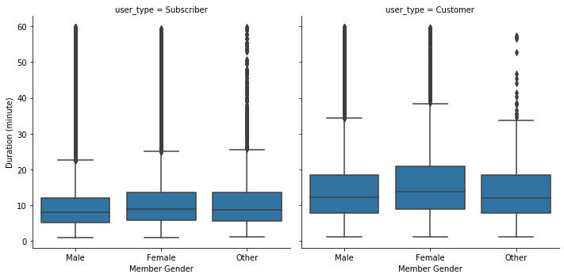

```python
# create facet Grid.
g = sb.FacetGrid(data = fordgobike_clean_df2, col = 'user_type', height = 5)
g.map(sb.boxplot, 'member_gender', 'duration_min',order=['Male','Female','Other']);
g.set_xlabels('Member Gender')
g.set_ylabels('Duration (minute)')
```

A multivariate boxplot views the comparable effect of user type of both Males and females on Trip Duration, show slight difference between male and female of Subscriber user, but it is noticable in Customer group, on the Trip Duration.

investigate the relation between Age and Gender and the effect on Trip duration.

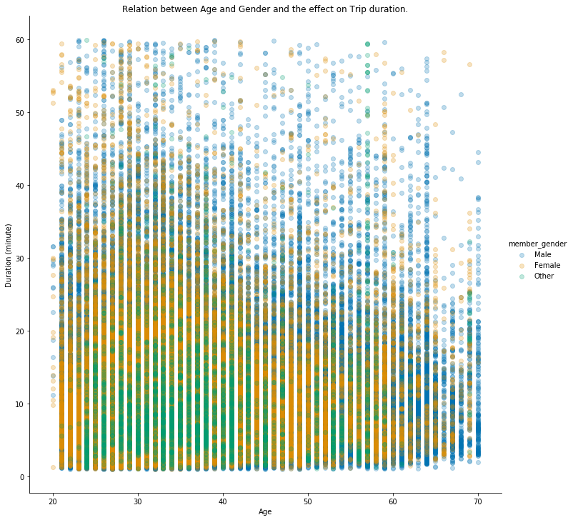

```python
# create faceted scatterplot.
# show the relation between Age and Gender and the effect on Trip duration.
g = sb.FacetGrid(data = fordgobike_clean_df2, hue = 'member_gender', height = 10,
                 palette = 'colorblind')
g.map(plt.scatter, 'age', 'duration_min', alpha=0.25)
g.add_legend();
plt.title('Relation between Age and Gender and the effect on Trip duration.');
plt.xlabel('Age');
plt.ylabel('Duration (minute)');
```

Faceted scatter plot to show the relation between Age and Gender and the effect on the Trip duration, view decreased trip duration with the increase of age, with male more distributed than female.

investigate the relation between User type and Age and the effect on Trip duration.

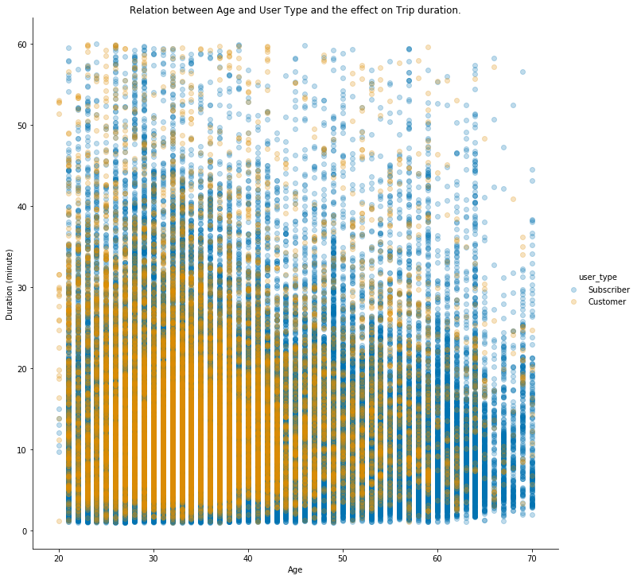

```python
# create faceted scatterplot show  relation between User type and Age
# and the effect on Trip duration.
g = sb.FacetGrid(data = fordgobike_clean_df2, hue = 'user_type', height = 10,
                 palette = 'colorblind')
g.map(plt.scatter, 'age', 'duration_min', alpha=0.25)
g.add_legend();
plt.title('Relation between Age and User Type and the effect on Trip duration.');
plt.xlabel('Age');
plt.ylabel('Duration (minute)');
```

Comparing the member Gender of both user types on the average of Trip Duration.

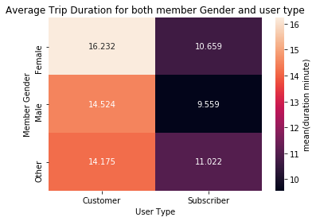

```python
# create heat map.
cat_means = fordgobike_clean_df2.groupby(['user_type', 'member_gender']).mean()['duration_min']
cat_means = cat_means.reset_index(name = 'num_var2_avg')
cat_means = cat_means.pivot(index = 'member_gender', columns = 'user_type',
                            values = 'num_var2_avg')
sb.heatmap(cat_means, annot = True, fmt = '.3f',
           cbar_kws = {'label' : 'mean(duration minute)'});
plt.title('Average Trip Duration for both member Gender and user type');
plt.xlabel('User Type');
plt.ylabel('Member Gender');
```

A heatmap views the higher Trip Duration average of Female Customer compared with Male Customer, while the Male Subscribers show the lowest Trip duration average compared with female Subscribers.

More look at the relationship between gender, user type, and Trip Duration.

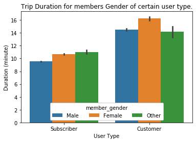

```python
ax = sb.barplot(data = fordgobike_clean_df2, x = 'user_type', y = 'duration_min', hue = 'member_gender')
ax.legend(loc = 8, ncol = 3, framealpha = 1, title = 'member_gender');
plt.title('Trip Duration for members Gender of certain user type.');
plt.xlabel('User Type');
plt.ylabel('Duration (minute)');
```

clustered bar chart views the higher Trip Duration of Female Customer compared with Male Customer, while the Male Subscribers show the lowest Trip duration compared with female and other Subscribers.

### Talk about some of the relationships you observed in this part of the investigation. Were there features that strengthened each other in terms of looking at your feature(s) of interest?

> I extended my investigation of Gender in this section by looking at the relation between Trip Duration, age, User Type, And Gender. The multivariate exploration here showed that there indeed is a positive effect of Gender, but in the dataset, this is initially hidden by the fact that there are a large Numbers of Male Users, which fetch a lower effect of gender on Trips Duration.

### Were there any interesting or surprising interactions between features?

> The other gender seems to have a surprising effect .

```python
#Storing Dataframe to a csv file for slide presentation.
fordgobike_clean_df2.to_csv('slide_deck-fordgobike-tripdata_clean.csv',encoding='utf-8', index=False)
```